# Exploratory data analysis

This is an initial exploratory analysis before building any models.

# Loading libraries

```r
source("feature_engineering.R")
```

[output not shown]

# Loading current data

| passengerid | survived | pclass | name | sex | age | sibsp | parch | ticket | fare | cabin | embarked |
| --- | --- | --- | --- | --- | --- | --- | --- | --- | --- | --- | --- |
| 1 | 0 | 3 | Braund, Mr. Owen Harris | male | 22 | 1 | 0 | A/5 21171 | 7.2500 |  | S |
| 2 | 1 | 1 | Cumings, Mrs. John Bradley (Florence Briggs Thayer) | Female | 38 | 1 | 0 | PC 17599 | 71.2833 | C85 | C |
| 3 | 1 | 3 | Heikkinen, Miss. Laina | women | 26 | 0 | 0 | STON/O2. 3101282 | 7.9250 |  | S |
| 4 | 1 | 1 | Futrelle, Mrs. Jacques Heath (Lily May Peel) | female_ | 35 | 1 | 0 | 113803 | 53.1000 | C123 | S |
| 5 | 0 | 3 | Allen, Mr. William Henry | male | 35 | 0 | 0 | 373450 | 8.0500 |  | S |
| 6 | 0 | 3 | Moran, Mr. James | male | NA | 0 | 0 | 330877 | 8.4583 |  | Q |

# Summary

```r
summary(train_data)
```

```
  passengerid       survived          pclass          name               sex                 age             sibsp
 Min.   :  1.0   Min.   :0.0000   Min.   :1.000   Length:936         Length:936         Min.   :  0.42   Min.   :0.0000
 1st Qu.:221.8   1st Qu.:0.0000   1st Qu.:2.000   Class :character   Class :character   1st Qu.: 20.00   1st Qu.:0.0000
 Median :445.5   Median :0.0000   Median :3.000   Mode  :character   Mode  :character   Median : 28.00   Median :0.0000
 Mean   :446.4   Mean   :0.3846   Mean   :2.315                                         Mean   : 29.78   Mean   :0.5192
 3rd Qu.:672.2   3rd Qu.:1.0000   3rd Qu.:3.000                                         3rd Qu.: 38.00   3rd Qu.:1.0000
 Max.   :891.0   Max.   :1.0000   Max.   :3.000                                         Max.   :194.00   Max.   :8.0000
                                  NA's   :9                                             NA's   :188
     parch          ticket               fare            cabin             embarked
 Min.   :0.000   Length:936         Min.   :  0.000   Length:936         Length:936
 1st Qu.:0.000   Class :character   1st Qu.:  7.896   Class :character   Class :character
 Median :0.000   Mode  :character   Median : 14.454   Mode  :character   Mode  :character
 Mean   :0.375                      Mean   : 31.647
 3rd Qu.:0.000                      3rd Qu.: 30.772
 Max.   :6.000                      Max.   :512.329
```

Our baseline for survival rate is 0.38, that is the “no information” chance of survival. Lets take a look at the what seems to be the categorical variables:

| category | len |
| --- | --- |
| pclass | 4 |
| name | 891 |
| sex | 10 |
| parch | 7 |
| cabin | 148 |
| embarked | 4 |

It looks we need the “name”, “sex” and “cabin” features in order to extract any meaninful information from it.

## Cleaning Name feature

What feature in the name may be an indicator for survival? Let’s take a look

```r
train_data[,head(name)]
```

```
[1] "Braund, Mr. Owen Harris"                             "Cumings, Mrs. John Bradley (Florence Briggs Thayer)"
[3] "Heikkinen, Miss. Laina"                              "Futrelle, Mrs. Jacques Heath (Lily May Peel)"
[5] "Allen, Mr. William Henry"                            "Moran, Mr. James"
```

Our first hypothesis: either alias (a well known subject) or its title is an indication for greater survival rate. Lets extract those and try to correlate with the survival rate.

### Defining new features from name

| name | title | has_nick |
| --- | --- | --- |
| Braund, Mr. Owen Harris | Mr | FALSE |
| Cumings, Mrs. John Bradley (Florence Briggs Thayer) | Mrs | TRUE |
| Heikkinen, Miss. Laina | Miss | FALSE |
| Futrelle, Mrs. Jacques Heath (Lily May Peel) | Mrs | TRUE |
| Allen, Mr. William Henry | Mr | FALSE |
| Moran, Mr. James | Mr | FALSE |
| McCarthy, Mr. Timothy J | Mr | FALSE |
| Palsson, Master. Gosta Leonard | Master | FALSE |
| Johnson, Mrs. Oscar W (Elisabeth Vilhelmina Berg) | Mrs | TRUE |
| Nasser, Mrs. Nicholas (Adele Achem) | Mrs | TRUE |

[output cut: 926 more lines]

### Correlation with survival

| title | N | V2 |
| --- | --- | --- |
| Mr | 541 | 0.1589649 |
| Mrs | 126 | 0.7857143 |
| Miss | 197 | 0.7055838 |
| Master | 43 | 0.5581395 |
| Don | 2 | 0.0000000 |
| Rev | 7 | 0.0000000 |
| Dr | 7 | 0.4285714 |
| Mme | 1 | 1.0000000 |
| Ms | 1 | 1.0000000 |
| Major | 2 | 0.5000000 |

[output cut: 7 more lines]

The top 6 titles, may constitute our base category, we leaver the remaining as the “other” category

| has_nick | N | V2 |
| --- | --- | --- |
| FALSE | 750 | 0.2920000 |
| TRUE | 186 | 0.7580645 |

Its seem our assumptions were correct, those with nickname or a distinctive title have a greater survival rate than those who don’t.

## Cleaning the sex variable

| sex | N |
| --- | --- |
| male | 314 |
| Female | 48 |
| women | 45 |
| female_ | 48 |
| woman | 48 |
| man | 88 |
| female | 126 |
| mal | 89 |
|  | 46 |
| Male | 84 |

| is_male | is_female | is_sex_unknown | N | rate |
| --- | --- | --- | --- | --- |
| TRUE | FALSE | FALSE | 575 | 0.1843478 |
| FALSE | TRUE | FALSE | 315 | 0.7428571 |
| FALSE | FALSE | TRUE | 46 | 0.4347826 |

The unknown sex could be inferred from the title, but not for all titles:

| title | V1 |
| --- | --- |
| Mr | 0.0000000 |
| Mrs | 1.0000000 |
| Miss | 1.0000000 |
| Master | 0.0000000 |
| Don | 0.0000000 |
| Rev | 0.0000000 |
| Dr | 0.1428571 |
| Mme | 1.0000000 |
| Ms | 1.0000000 |
| Major | 0.0000000 |

[output cut: 6 more lines]

## Cabin variable

| cabin | N | V2 |
| --- | --- | --- |
| TRUE | 726 | 0.3030303 |
| FALSE | 210 | 0.6666667 |

## Embarked variable

| embarked | N | V2 |
| --- | --- | --- |
| S | 676 | 0.3372781 |
| C | 176 | 0.5454545 |
| Q | 82 | 0.4146341 |
|  | 2 | 1.0000000 |

## Pclass variable

| pclass | N | V2 |
| --- | --- | --- |
| 3 | 516 | 0.2480620 |
| 1 | 224 | 0.6339286 |
| 2 | 187 | 0.4705882 |
| NA | 9 | 0.2222222 |

## Parch variable

| parch | N | V2 |
| --- | --- | --- |
| 0 | 715 | 0.3454545 |
| 1 | 123 | 0.5528455 |
| 2 | 83 | 0.4939759 |
| 5 | 5 | 0.2000000 |
| 3 | 5 | 0.6000000 |
| 4 | 4 | 0.0000000 |
| 6 | 1 | 0.0000000 |

## ticket variable

```r
train_data[,head(ticket)]
```

```
[1] "A/5 21171"        "PC 17599"         "STON/O2. 3101282" "113803"           "373450"           "330877"
```

## ticket prefix

| category | N | rate | V3 |
| --- | --- | --- | --- |
| SO/C | 1 | 1.0000000 | 14885.0000 |
| SW/PP | 1 | 1.0000000 | 751.0000 |
| SC | 1 | 1.0000000 | 1748.0000 |
| S.W./PP | 1 | 1.0000000 | 752.0000 |
| F.C.C. | 5 | 0.8000000 | 13529.2000 |
| PP | 3 | 0.6666667 | 7815.3333 |
| SC/AH | 3 | 0.6666667 | NA |
| PC | 63 | 0.6349206 | 17614.6032 |
| STON/O2. | 6 | 0.5000000 | 3101280.6667 |
| SC/Paris | 4 | 0.5000000 | 2133.0000 |

[output cut: 34 more lines]

### survival rate by ticket order number and prefix

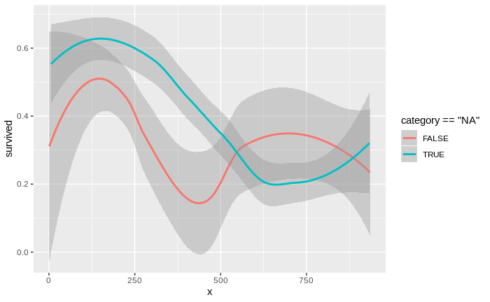

# Moving average of survival rate by ticket number order for tickets without a prefix

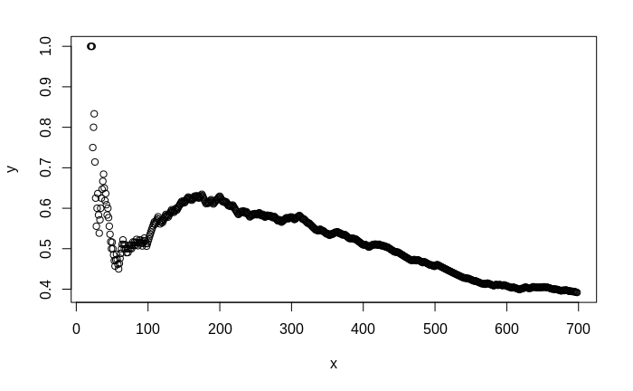

# Moving average of survival rate by ticket number order for tickets with a prefix

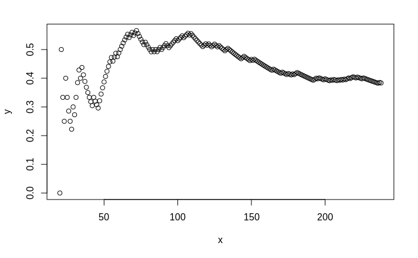

# Moving average of survival rate by age order

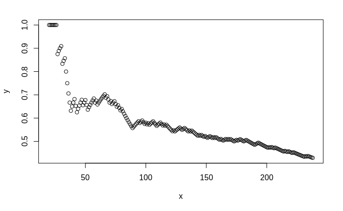

# Exploratory model

```r
summary(transformed$data)
```

```
      age            sibsp             fare          title_Mr       title_Miss      title_Mrs       title_Master    title_Rev        title_Dr       title_other
 Min.   :  0.0   Min.   :0.0000   Min.   :  0.000   Mode :logical   Mode :logical   Mode :logical   Mode :logical   Mode :logical   Mode :logical   Mode :logical
 1st Qu.:  6.0   1st Qu.:0.0000   1st Qu.:  7.896   FALSE:395       FALSE:739       FALSE:810       FALSE:893       FALSE:929       FALSE:929       FALSE:921
 Median : 24.0   Median :0.0000   Median : 14.454   TRUE :541       TRUE :197       TRUE :126       TRUE :43        TRUE :7         TRUE :7         TRUE :15
 Mean   : 23.8   Mean   :0.5192   Mean   : 31.647
 3rd Qu.: 35.0   3rd Qu.:1.0000   3rd Qu.: 30.772
 Max.   :194.0   Max.   :8.0000   Max.   :512.329
  pclass_3        pclass_1        pclass_2       pclass_NA       embarked_S      embarked_C      embarked_Q       parch_0         parch_1         parch_2
 Mode :logical   Mode :logical   Mode :logical   Mode :logical   Mode :logical   Mode :logical   Mode :logical   Mode :logical   Mode :logical   Mode :logical
 FALSE:420       FALSE:712       FALSE:749       FALSE:927       FALSE:260       FALSE:760       FALSE:854       FALSE:221       FALSE:813       FALSE:853
 TRUE :516       TRUE :224       TRUE :187       TRUE :9         TRUE :676       TRUE :176       TRUE :82        TRUE :715       TRUE :123       TRUE :83



 parch_other      has_nick        is_male        is_female       is_sex_unknown  has_cabin       ticket_category  ticket_value       no_age
 Mode :logical   Mode :logical   Mode :logical   Mode :logical   Mode :logical   Mode :logical   Mode :logical   Min.   :      0   Mode :logical
 FALSE:921       FALSE:750       FALSE:361       FALSE:621       FALSE:890       FALSE:210       FALSE:698       1st Qu.:      0   FALSE:748
 TRUE :15        TRUE :186       TRUE :575       TRUE :315       TRUE :46        TRUE :726       TRUE :238       Median :  36897   TRUE :188
                                                                                                                 Mean   : 191225
                                                                                                                 3rd Qu.: 345773
                                                                                                                 Max.   :3101298
```

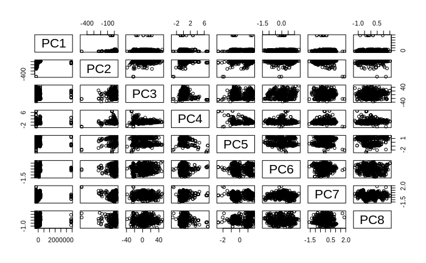

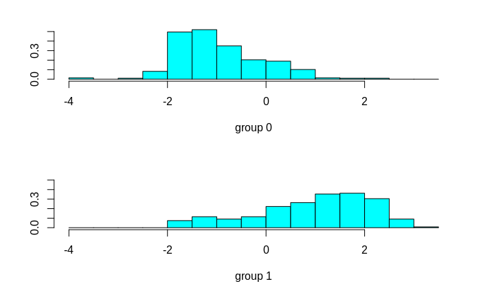

```r
confusionMatrix(pred.train$class,as.factor(regressors$target),positive="1")
```

```
Confusion Matrix and Statistics

          Reference
Prediction   0   1
         0 367  62
         1  45 181

               Accuracy : 0.8366
                 95% CI : (0.8061, 0.8641)
    No Information Rate : 0.629
    P-Value [Acc > NIR] : <2e-16

                  Kappa : 0.6449
 Mcnemar's Test P-Value : 0.1219

            Sensitivity : 0.7449
            Specificity : 0.8908
         Pos Pred Value : 0.8009
         Neg Pred Value : 0.8555
             Prevalence : 0.3710
         Detection Rate : 0.2763
   Detection Prevalence : 0.3450
      Balanced Accuracy : 0.8178

       'Positive' Class : 1
```

```r
c(acc_train,acc_validate)
```

```
[1] 0.8366412 0.8220641
```

Let’s build a random forest model with cross-validation and perform an extensive gridsearch.

```r
# train model
control <- trainControl(method="repeatedcv", number=11, repeats=9)
tunegrid <- expand.grid(.mtry=c(seq(1,10,3)), .ntree=c(100,400,900))
metric <- "Accuracy"
seed=814
set.seed(seed)
registerDoMC(cores=7)
custom <- train(factor(target) ~., data=input, method=customRF, metric=metric, tuneGrid=tunegrid, trControl=control)
ggplot(custom$results,aes(x=mtry,y=ntree,
                          size=-1/log(Accuracy),
                          color=-1/log(Accuracy/max(Accuracy+AccuracySD))))+geom_point()+geom_point(aes(size=-1/log(Accuracy+AccuracySD)),shape=1)
```

[output not shown]

```r
plot_grid_search(mtry_grid = seq(10,100,1)/10,ntree_grid = seq(100,900,10), results=custom$results)
```

[output not shown]

```r
# train model
control <- trainControl(method="repeatedcv", number=11, repeats=9)
#tunegrid <- expand.grid(.mtry=c(seq(1,15,3)), .ntree=c(100, 400,900, 1600, 2500))
tunegrid <- expand.grid(.mtry=c(seq(3,8,1)), .ntree=c(seq(100,700,100)))
metric <- "Accuracy"
seed=814
set.seed(seed)
registerDoMC(cores=7)
custom.zoom <- train(factor(target) ~., data=input, method=customRF, metric=metric, tuneGrid=tunegrid, trControl=control)
#summary(custom)
ggplot(custom.zoom$results,aes(x=mtry,y=ntree,
                          size=-1/log(Accuracy),
                          color=-1/log(Accuracy/max(Accuracy+AccuracySD))))+geom_point()+geom_point(aes(size=-1/log(Accuracy+AccuracySD)),shape=1)
```

[output not shown]

```r
plot_grid_search(mtry_grid = seq(20,90,1)/10,ntree_grid = seq(100,700,10), results=custom.zoom$results)
```

[output not shown]

```r
results=data.table(custom.zoom$results)
results[mtry == custom.zoom$bestTune$mtry][ntree==custom.zoom$bestTune$ntree]
```

[output not shown]

What about RF without pre-processing?

```r
control <- trainControl(method="repeatedcv", number=11, repeats=9)
#tunegrid <- expand.grid(.mtry=c(seq(1,15,3)), .ntree=c(100, 400,900, 1600, 2500))
tunegrid <- expand.grid(.mtry=c(seq(1,20,3)), .ntree=c(50,100,400,900,1600))
metric <- "Accuracy"
seed=814
set.seed(seed)
registerDoMC(cores=7)
custom.no_preprocess <- train(factor(target) ~., data=input.no_preproces, method=customRF, metric=metric, tuneGrid=tunegrid, trControl=control)
#summary(custom)
ggplot(custom.no_preprocess$results,aes(x=mtry,y=ntree,
                          size=-1/log(Accuracy),
                          color=-1/log(Accuracy/max(Accuracy+AccuracySD))))+geom_point()+geom_point(aes(size=-1/log(Accuracy+AccuracySD)),shape=1)
```

[output not shown]

```r
plot_grid_search(mtry_grid = seq(10,210,1)/10,ntree_grid = seq(100,1600,50), results=custom.no_preprocess$results)
```

[output not shown]

```r
results=data.table(custom.no_preprocess$results)
results[mtry == custom.no_preprocess$bestTune$mtry][ntree==custom.no_preprocess$bestTune$ntree]
```

[output not shown]

```r
control <- trainControl(method="repeatedcv", number=11, repeats=9)
tunegrid <- expand.grid(.mtry=c(seq(4,15,1)), .ntree=c(100,200,250,300,350,400,450,500))
metric <- "Accuracy"
seed=814
set.seed(seed)
registerDoMC(cores=7)
input.no_preproces=cbind(target,transformed$data)
custom.no_preprocess_pan_grid <- train(factor(target) ~., data=input.no_preproces, method=customRF, metric=metric, tuneGrid=tunegrid, trControl=control)
#summary(custom)
ggplot(custom.no_preprocess_pan_grid$results,aes(x=mtry,y=ntree,
                          size=-1/log(Accuracy),
                          color=-1/log(Accuracy/max(Accuracy+AccuracySD))))+geom_point()+geom_point(aes(size=-1/log(Accuracy+AccuracySD)),shape=1)
```

[output not shown]

```r
plot_grid_search(mtry_grid = seq(30,160,1)/10,ntree_grid = seq(50,550,10), results=custom.no_preprocess_pan_grid$results)
```

[output not shown]

```r
results=data.table(custom.no_preprocess_pan_grid$results)
#results[mtry >= 7 & mtry < 13]
results[mtry == custom.no_preprocess_pan_grid$bestTune$mtry][ntree==custom.no_preprocess_pan_grid$bestTune$ntree]
```

[output not shown]

```r
control <- trainControl(method="repeatedcv", number=11, repeats=9)
#tunegrid <- expand.grid(.mtry=c(seq(1,15,3)), .ntree=c(100, 400,900, 1600, 2500))
tunegrid <- expand.grid(.mtry=c(seq(7,11,1)), .ntree=c(300,325,350,375,400,425,450))
metric <- "Accuracy"
seed=814
set.seed(seed)
registerDoMC(cores=7)
input.no_preproces=cbind(target,transformed$data)
custom.no_preprocess_zoom <- train(factor(target) ~., data=input.no_preproces, method=customRF, metric=metric, tuneGrid=tunegrid, trControl=control)
#summary(custom)
ggplot(custom.no_preprocess_zoom$results,aes(x=mtry,y=ntree,
                          size=-1/log(Accuracy),
                          color=-1/log(Accuracy/max(Accuracy+AccuracySD))))+geom_point()+geom_point(aes(size=-1/log(Accuracy+AccuracySD)),shape=1)
```

[output not shown]

```r
plot_grid_search(mtry_grid = seq(70,120,1)/10,ntree_grid = seq(300,500,10), results=custom.no_preprocess_zoom$results)
```

[output not shown]

```r
results=data.table(custom.no_preprocess_zoom$results)
results[mtry == custom.no_preprocess_zoom$bestTune$mtry][ntree==custom.no_preprocess_zoom$bestTune$ntree]
```

[output not shown]

```r
control <- trainControl(method="repeatedcv", number=11, repeats=9)
#tunegrid <- expand.grid(.mtry=c(seq(1,15,3)), .ntree=c(100, 400,900, 1600, 2500))
tunegrid <- expand.grid(.mtry=c(seq(9,12,1)), .ntree=c(200,250,275,300,325,350,375,400))
metric <- "Accuracy"
seed=814
set.seed(seed)
registerDoMC(cores=7)
input.no_preproces=cbind(target,transformed$data)
custom.no_preprocess_zoom2 <- train(factor(target) ~., data=input.no_preproces, method=customRF, metric=metric, tuneGrid=tunegrid, trControl=control)
#summary(custom)
all=rbind(custom.no_preprocess$results,
  custom.no_preprocess_pan_grid$results,
          custom.no_preprocess_zoom$results,
             custom.no_preprocess_zoom2$results)
ggplot(all,aes(x=mtry,y=ntree,
                          size=-1/log(Accuracy),
                          color=-1/log(Accuracy/max(Accuracy+AccuracySD))))+geom_point()+geom_point(aes(size=-1/log(Accuracy+AccuracySD)),shape=1)
```

[figure not shown]

| mtry | ntree | Accuracy | Kappa | AccuracySD | KappaSD |
| --- | --- | --- | --- | --- | --- |
| 10 | 200 | 0.852698 | 0.6834854 | 0.03595973 | 0.07909085 |

# Train model at the exact sweet spot

```r
c(input.train[,mean(target)],
input.validate[,mean(target)])
```

```
[1] 0.3709924 0.4163701
```

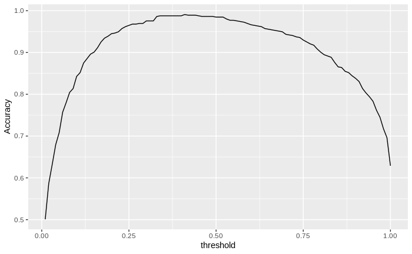

| tr | ACC |
| --- | --- |
| 0.41 | 0.9908397 |
| 0.41 | 0.9908397 |

Let’s compare with the lda ROC

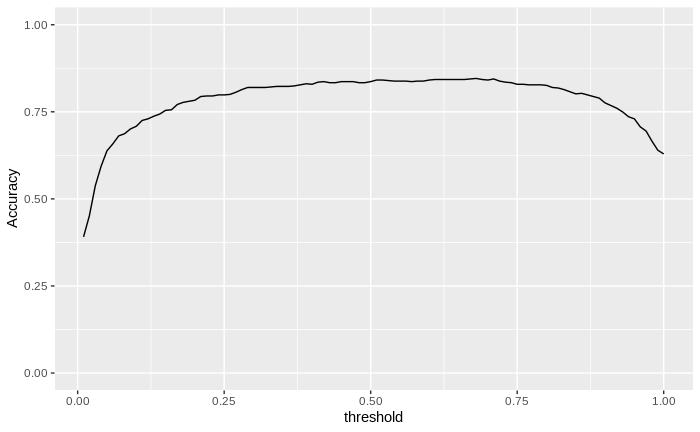

| tr | ACC |
| --- | --- |
| 0.68 | 0.8458015 |
| 0.68 | 0.8458015 |

Since we have a limited seats on the boat we can get the cutoff probability from the number of possible people that can be saved.

| rate | total_survivors |
| --- | --- |
| 0.9835391 | 239 |

Graphically

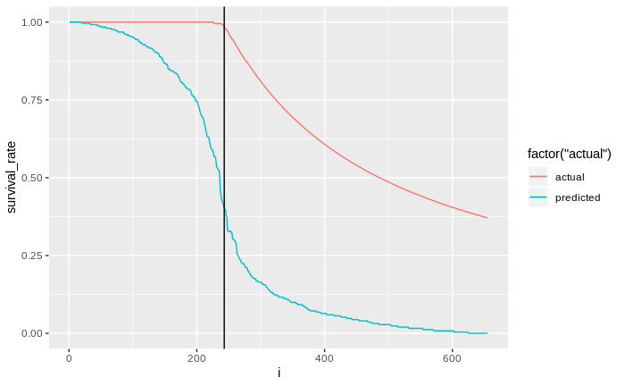

```r
confusionMatrix(table(tdata[1:limit]$y>0.41,tdata[1:limit]$target=="1"),positive="TRUE")
```

```
Confusion Matrix and Statistics


        FALSE TRUE
  FALSE   410    4
  TRUE      2  239

               Accuracy : 0.9908
                 95% CI : (0.9802, 0.9966)
    No Information Rate : 0.629
    P-Value [Acc > NIR] : <2e-16

                  Kappa : 0.9803
 Mcnemar's Test P-Value : 0.6831

            Sensitivity : 0.9835
            Specificity : 0.9951
         Pos Pred Value : 0.9917
         Neg Pred Value : 0.9903
             Prevalence : 0.3710
         Detection Rate : 0.3649
   Detection Prevalence : 0.3679
      Balanced Accuracy : 0.9893

       'Positive' Class : TRUE
```

```r
#tdata[,sum(target)]
confusionMatrix(table(tdata[1:limit]$y>0.41,tdata[1:limit]$target=="1"),positive="TRUE")
```

```
Confusion Matrix and Statistics


        FALSE TRUE
  FALSE   140   25
  TRUE     24   92

               Accuracy : 0.8256
                 95% CI : (0.7761, 0.8681)
    No Information Rate : 0.5836
    P-Value [Acc > NIR] : <2e-16

                  Kappa : 0.6408
 Mcnemar's Test P-Value : 1

            Sensitivity : 0.7863
            Specificity : 0.8537
         Pos Pred Value : 0.7931
         Neg Pred Value : 0.8485
             Prevalence : 0.4164
         Detection Rate : 0.3274
   Detection Prevalence : 0.4128
      Balanced Accuracy : 0.8200

       'Positive' Class : TRUE
```

Graphically

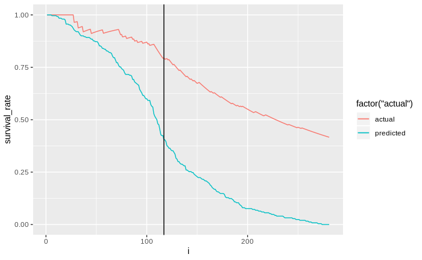

```r
tdata[1:sum(target)][,mean(target)]
```

```
[1] 0.7948718
```

Even though we have conducted a cross-validation the model seems to be considerably overfitted.

Let’s compare the performance to the LDA model

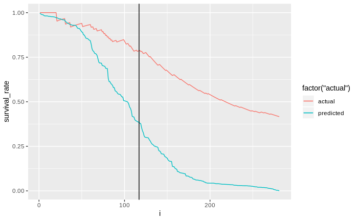

```r
confusionMatrix(table(tdata[1:limit]$y>0.41,tdata[1:limit]$target=="1"),positive="TRUE")
```

```
Confusion Matrix and Statistics


        FALSE TRUE
  FALSE   140   30
  TRUE     24   87

               Accuracy : 0.8078
                 95% CI : (0.7568, 0.8522)
    No Information Rate : 0.5836
    P-Value [Acc > NIR] : 1.091e-15

                  Kappa : 0.6017
 Mcnemar's Test P-Value : 0.4962

            Sensitivity : 0.7436
            Specificity : 0.8537
         Pos Pred Value : 0.7838
         Neg Pred Value : 0.8235
             Prevalence : 0.4164
         Detection Rate : 0.3096
   Detection Prevalence : 0.3950
      Balanced Accuracy : 0.7986

       'Positive' Class : TRUE
```

```r
tdata[1:sum(target)][,mean(target)]
```

```
[1] 0.7863248
```

The lda model seems to be less overfitted than the RF model, the performances of both models are quite similar on the validation set. We observe a significant drop in the predicted survival probability between survivors and desceased. Instead of predicting the number of survivors, the output of the model is a ranked list of passengers from the most probable to survive to the least. The expected number of survivors depends on the number of boats available.

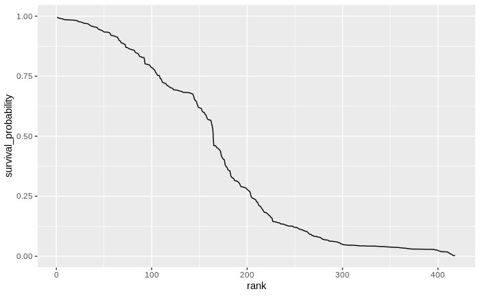

Beyond the 150th top passenger the survival probability drops significantly.

| passengerid | pclass | name | sex | age | sibsp | parch | ticket | fare | cabin | embarked | survival_probability | rank |
| --- | --- | --- | --- | --- | --- | --- | --- | --- | --- | --- | --- | --- |
| 1235 | 1 | Cardeza, Mrs. James Warburton Martinez (Charlotte Wardle Drake) | female | 58.00 | 0 | 1 | PC 17755 | 512.3292 | B51 B53 B55 | C | 0.9966482 | 1 |
| 1076 | 1 | Douglas, Mrs. Frederick Charles (Mary Helene Baxter) | female | 27.00 | 1 | 1 | PC 17558 | 247.5208 | B58 B60 | C | 0.9922809 | 2 |
| 1042 | 1 | Earnshaw, Mrs. Boulton (Olive Potter) | female | 23.00 | 0 | 1 | 11767 | 83.1583 | C54 | C | 0.9915231 | 3 |
| 1164 | 1 | Clark, Mrs. Walter Miller (Virginia McDowell) | female | 26.00 | 1 | 0 | 13508 | 136.7792 | C89 | C | 0.9911107 | 4 |
| 1206 | 1 | White, Mrs. John Stuart (Ella Holmes) | female | 55.00 | 0 | 0 | PC 17760 | 135.6333 | C32 | C | 0.9894643 | 5 |
| 951 | 1 | Chaudanson, Miss. Victorine | female | 36.00 | 0 | 0 | PC 17608 | 262.3750 | B61 | C | 0.9889493 | 6 |
| 1256 | 1 | Harder, Mrs. George Achilles (Dorothy Annan) | female | 25.00 | 1 | 0 | 11765 | 55.4417 | E50 | C | 0.9879839 | 7 |
| 966 | 1 | Geiger, Miss. Amalie | female | 35.00 | 0 | 0 | 113503 | 211.5000 | C130 | C | 0.9864826 | 8 |
| 1303 | 1 | Minahan, Mrs. William Edward (Lillian E Thorpe) | female | 37.00 | 1 | 0 | 19928 | 90.0000 | C78 | Q | 0.9852053 | 9 |
| 1242 | 1 | Greenfield, Mrs. Leo David (Blanche Strouse) | female | 45.00 | 0 | 1 | PC 17759 | 63.3583 | D10 D12 | C | 0.9850321 | 10 |

[output cut: 140 more lines]